# Day 1, Session 3: Data Visualization in R

## Plotting a function

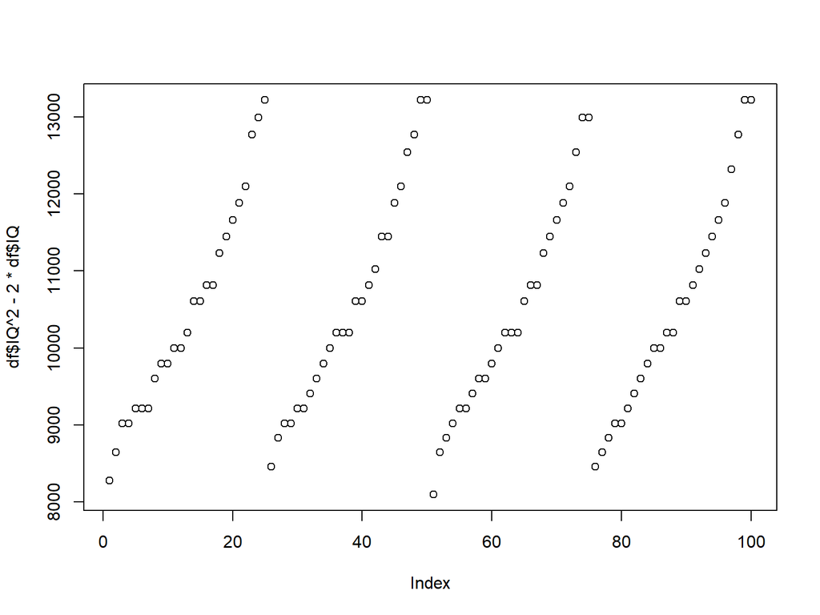

```r
plot(df$IQ^2-2*df$IQ)
```

## Box and whiskers plot

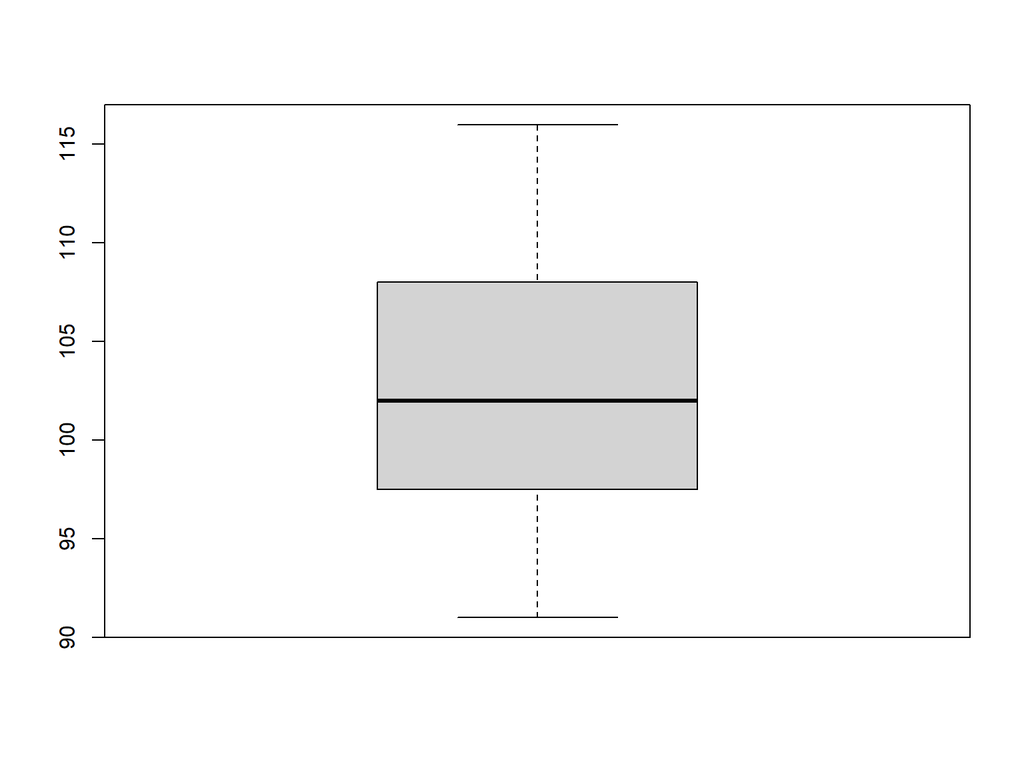

```r
boxplot(df$IQ)
```

## Let’s display a Box and whiskers plot by group

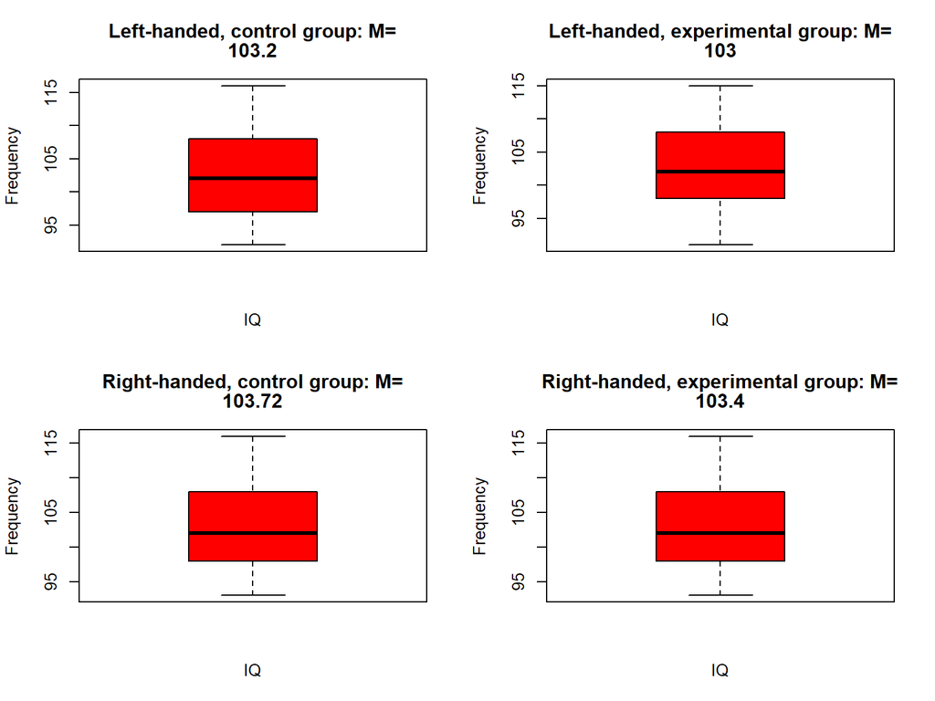

```r
par(mfrow=c(2, 2))
boxplot(df[df$DominantHand=="lefthanded" & df$Manipulation=="control_group",]$IQ,
        xlab="IQ",
        ylab="Frequency",
        main=c("Left-handed, control group: M=",
               mean(df[df$DominantHand=="lefthanded" & df$Manipulation=="control_group",]$IQ)),
        col="red")

boxplot(df[df$DominantHand=="lefthanded" & df$Manipulation=="experimental_group",]$IQ,
        xlab="IQ",
        ylab="Frequency",
        main=c("Left-handed, experimental group: M=",
               mean(df[df$DominantHand=="lefthanded" & df$Manipulation=="experimental_group",]$IQ)),
        col="red")

boxplot(df[df$DominantHand=="righthanded" & df$Manipulation=="control_group",]$IQ,
        xlab="IQ",
        ylab="Frequency",
        main=c("Right-handed, control group: M=",
               mean(df[df$DominantHand=="righthanded" & df$Manipulation=="control_group",]$IQ)),
        col="red")

boxplot(df[df$DominantHand=="righthanded" & df$Manipulation=="experimental_group",]$IQ,
        xlab="IQ",
        ylab="Frequency",
        main=c("Right-handed, experimental group: M=",
               mean(df[df$DominantHand=="righthanded" & df$Manipulation=="experimental_group",]$IQ)),
        col="red")
```

```r
par(mfrow=c(1,1))
```

## The same plot, with much less typing - lattice

- The formula reads as: IQ as a function of the levels of the Handedness factor, grouped by the levels of the Manipulation factor

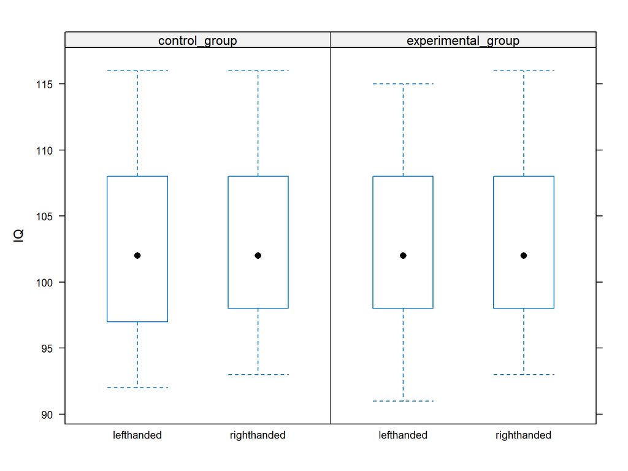

```r
library(lattice) # load the lattice package
bwplot(IQ ~ DominantHand | Manipulation, # the first argument is the formula defining what to display
       data=df) # the second argument is the data frame
```

## In the same package: scatterplot by category

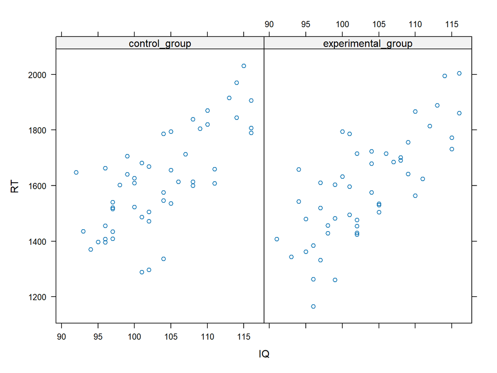

```r
xyplot(RT ~ IQ | Manipulation,
       data=df)
```

## ggplot2

## ggplot2

- A package written based on the book GRAMMAR OF GRAPHICS (Wilkinson, 1999)
- Currently the best and most widely used package for graphical display

## ggplot2

- Every plot has at least three basic components:
  - data
  - mapping variables onto axis coordinates, color, and size: aes
  - the way each observation should be displayed (points, lines, bars…): geom

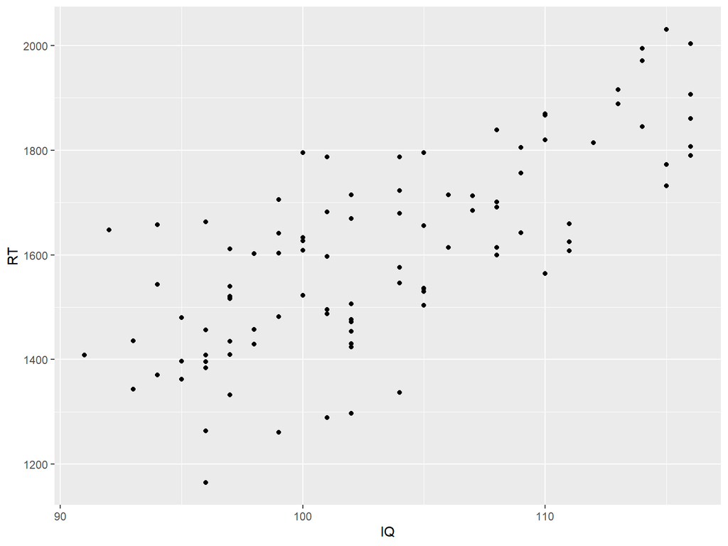

```r
library (ggplot2) # load the package

ggplot(df, # define which data frame to use
       aes(x = IQ, y = RT)) + # map variables onto axes
geom_point() # define how the values should be displayed: here, as points
```

## ggplot layers

- We can build a plot by adding layer upon layer
- Using “+” to add layers

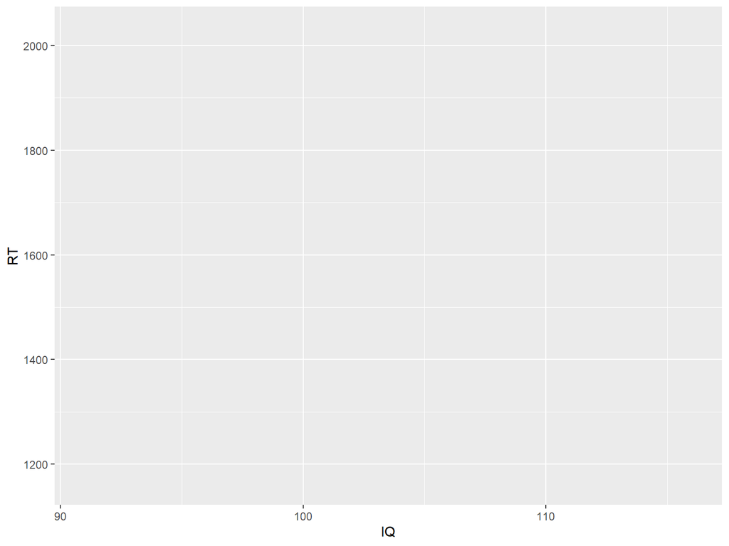

```r
g0 = ggplot(df, aes(x=IQ, y=RT)) # save the base plot into a variable
g0 # we see that only the axes are there
```

- Make it more appealing to the eye
  - We will come back to this

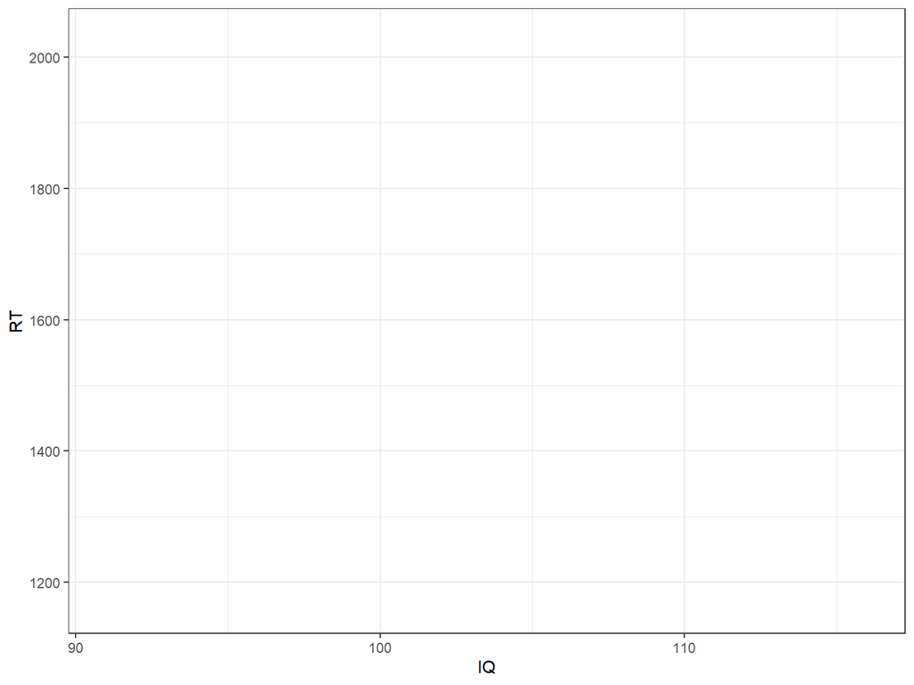

```r
g0 = ggplot(df, aes(x=IQ, y=RT)) + theme_bw()
g0
```

## Let’s add points

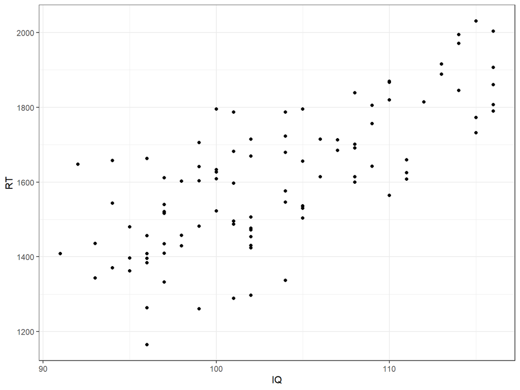

```r
g1 = g0 + # we add new layers using the + sign
    geom_point() # to display points (scatterplot)
g1
```

## Let’s add a title and axis labels

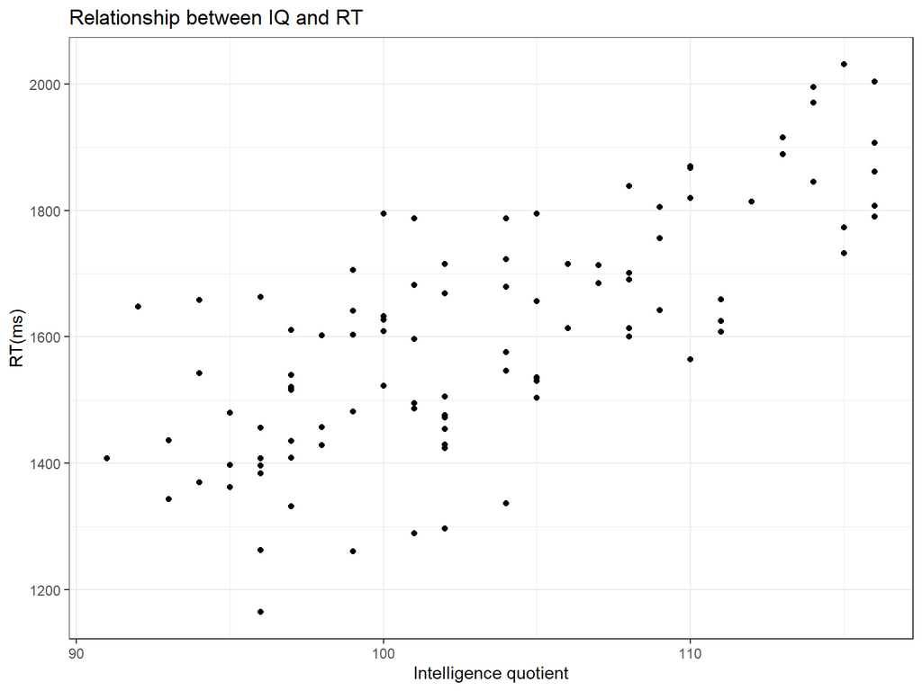

```r
g2 = g1 +
  ggtitle("Relationship between IQ and RT") + # give the plot a title
  xlab("Intelligence quotient") + # give the x-axis a title
  ylab("RT(ms)") # give the y-axis a title

g2
```